# What’s the most effective psychotherapy for depression?

- **1. Interpersonal Therapy**
  - Improve relationships and address interpersonal difficulties.
- **2. Psychodynamic Therapy**
  - Explore how past experiences shape current emotions and relationships.
- **3. Problem-Solving Therapy**
  - Identify problems and develop practical solutions.
- **4. Supportive Therapy**
  - Provide emotional support and strengthen coping.

## Depression Clinical Trial

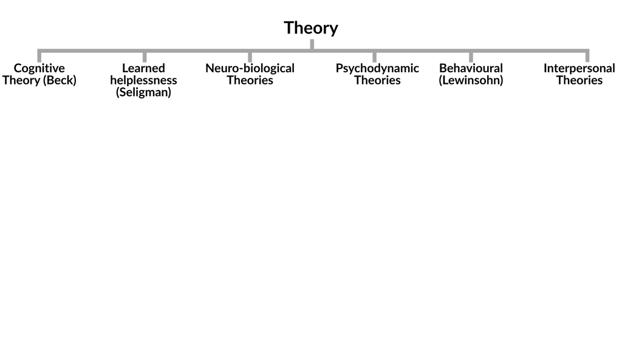

## Depression Clinical Trial

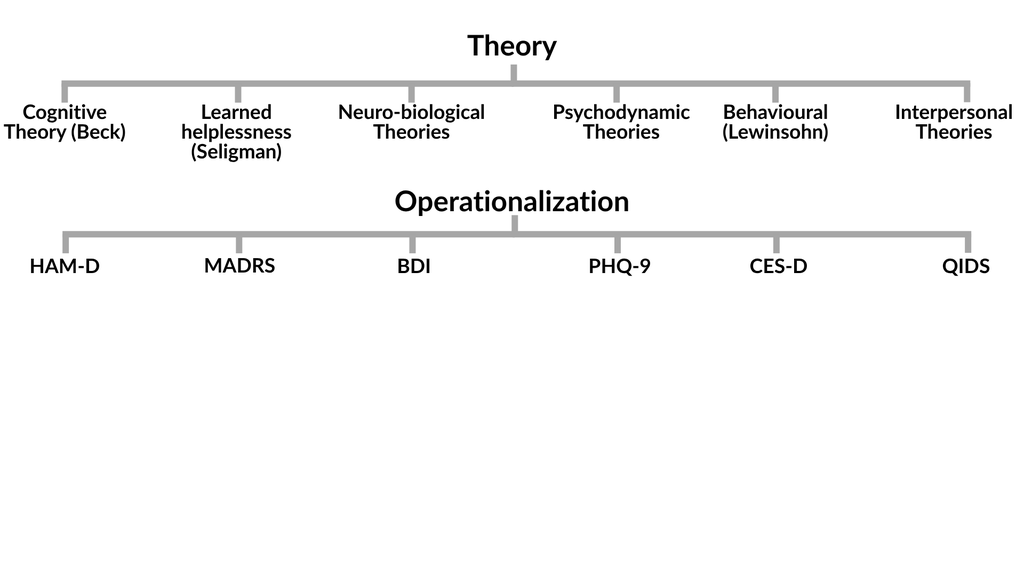

## Depression Clinical Trial

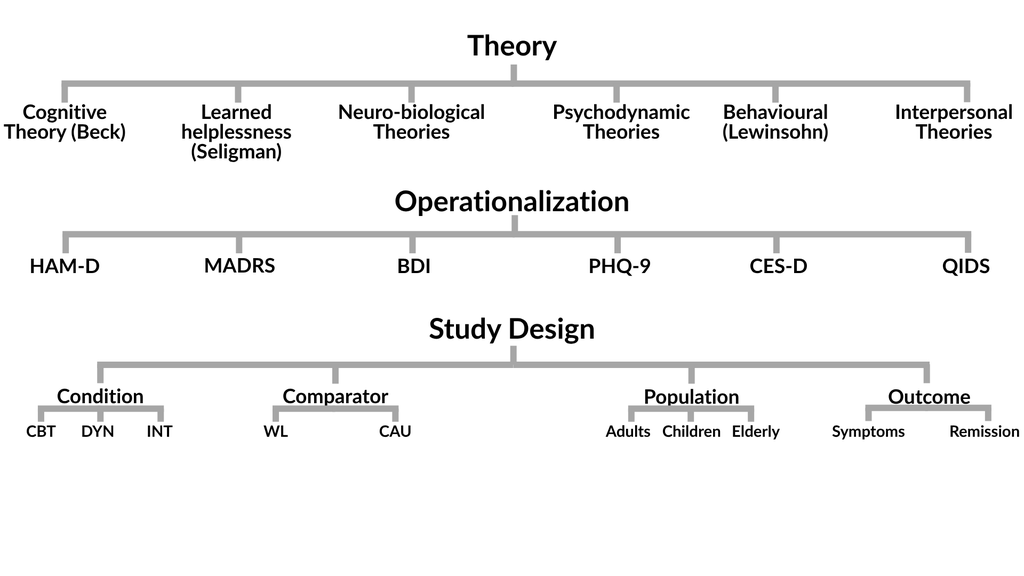

## Depression Clinical Trial

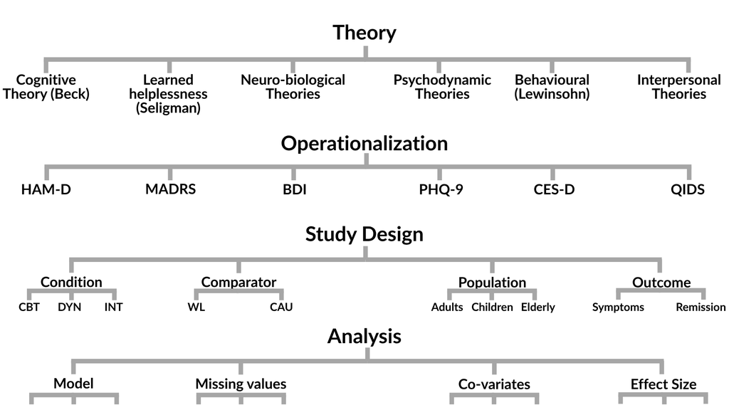

## Psychology’s Credibility Crisis

- **Theory crisis**
  - Too many theories, often vague and too flexible
- **Validity crisis**
  - Too many measures, often with uncertain validity or reliability
- **Replication crisis**
  - Many findings do not replicate consistently

## Replication Crisis

- **Open Science Collaboration, 2015**
  - 36% of effects replicated
  - Effect sizes were ~ 50% smaller

A decade later

↓

- **Tyner et al., 2026**
  - 49% of effects replicated
  - Effect sizes were ~ 60% smaller

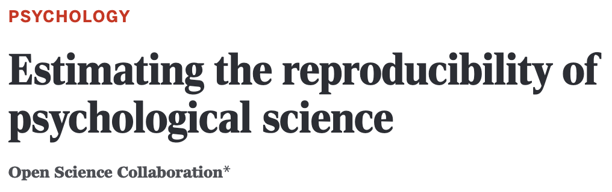

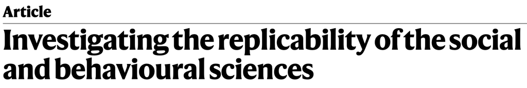

## Replication Crisis

### Causes:

- Questionable Research Practices
- Publication bias
- “Publish or perish!”

⬇

**Inflation of false positives**

# But there is another important cause

## Hurricane Katrina (2005)

[figure not shown]

## A surprising discovery

[figure not shown]

- According to the authors (Jung et al., 2014):
  1. Female-named Hurricanes $\rightarrow$ perceived as **less risky and intense**
  2. **Gender stereotypes** reduce **preparedness** (fewer precautions $\rightarrow$ more deaths)

## But then…

[figure not shown]

**But data & code were open!**

## What went wrong?

- The original analysis was **correct** and **reasonable**

### BUT

- It relied on **arbitrary analysis choices**
- Only **37** out of **>1,700** valid analyses were **significant** (Simonsohn et al., 2020)

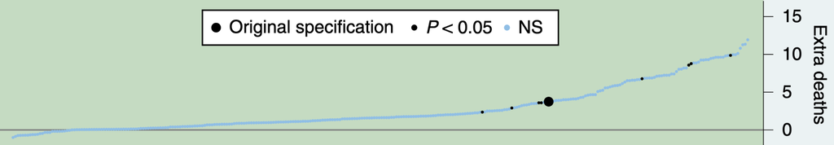

**The problem**

**Researcher degrees of freedom:** Every **equally justifiable choice** a researcher makes during the research process, which can drastically alter the final results. (Simmons et al., 2011)

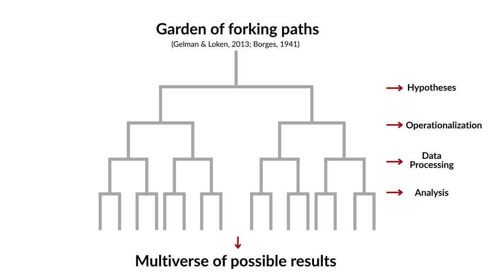

## But there is still one issue…

$\Rightarrow$ The Multiple Comparisons Problem

[Interactive Demo](https://01a048c7-7c03-2b6f-7388-2b05257dd030.share.connect.posit.cloud/)

## The proposed solution

[figure not shown]

## PIMA

- **Adjusts p-values** across many significance tests
  - Accounts for the *garden of forking paths*
- **Controls false positives**
  - Keeps Type I error $\leq 5\%$
- Maintains **good statistical power**
- Enables **selective inference**
  - Lets us draw valid conclusions from significant results

# What’s the most effective psychotherapy for depression?

## Interpersonal Therapy Depression RCT

[figure not shown]

- **n = 123** adults with MDD | **Multicenter Trial, USA** (Elkin et al., 1989)
- **Therapy Efficacy**:
  - **Depressive symptoms**: **g = 0.43**, 95% CI [0.07, 0.79], **p = 0.018**
  - **Recovery Rate**: 43% IPT vs 21% Control group

## This Meta-Analysis

- **Selection criteria**
  - **Therapy**: Interpersonal
  - **Control**: All
  - **Scope**: All therapy formats & outcome ratings
  - **Risk of Bias**: High risk excluded
- **Statistical Choices**
  - **Model**: Random-effects
  - **$\tau$ Estimator**: DerSimonian-Laird (DL)
  - **Aggregation coefficient**: $\rho$ = 0.3

## The Multiverse Reality

- This result was just **one of 36 plausible meta-analyses**
- All 36 meta-analyses were **equally reasonable**
- Considering the full meta-analytic multiverse **changes the conclusion**

Significant original p-value $\Rightarrow$ Adjusted p = 0.20 (**Not significant**)

# What’s the most effective psychotherapy for depression?

# What’s the most effective psychotherapy for depression?

$\Rightarrow$ Let’s explore the Multiverse!

## Depression Psychotherapies Multiverse

**Original Dataset** (Plessen et al., 2023)

- 413 RCTs, from 1977 to 2021
- 1206 Effect Sizes
- 7 Psychoterapies

**Multiverse**

- **756 Meta-Analyses**

## Take-home messages

- Results depend on **researcher’s choices**
- If several choices are reasonable, **include that uncertainty**
- **Multiverse analysis** shows how results change
- **PIMA** allows **valid inference** across the multiverse

$\Rightarrow$ But no statistical method can fix weak theory, poor measurement, or low-quality data!

## Upcoming

- Multiverse Book (Springer) by 2027 (?)
- Inferential Multiverse Meta-Analysis paper  
  & **R package** (*flipmeta*) on the way!
- My PhD project on Multiverse Meta-Analysis  
  of EMDR efficacy on PTSD

[figure not shown]

[Leave your email for updates](https://docs.google.com/forms/d/e/1FAIpQLSeBLAS4vov2QrVV3RcGCAa16kpyqLv5SeO8OsYLM_iR9QnjIw/viewform?usp=sharing&ouid=102004395540183102175)

[figure not shown]

## Thanks to

**Gianmarco Altoè**

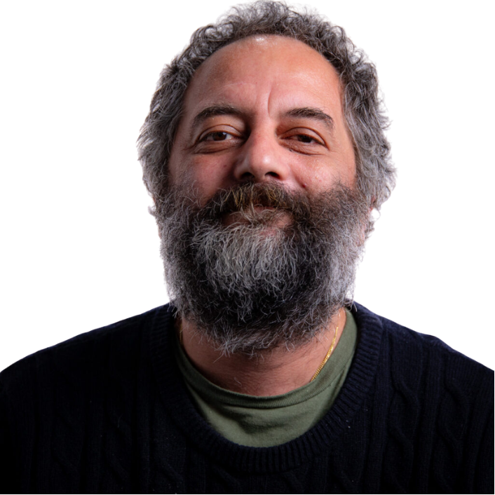

## Thanks to

**Filippo Gambarota**

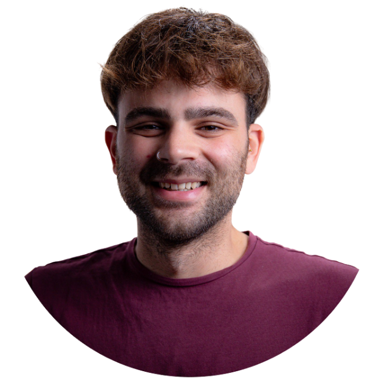

**Livio Finos**

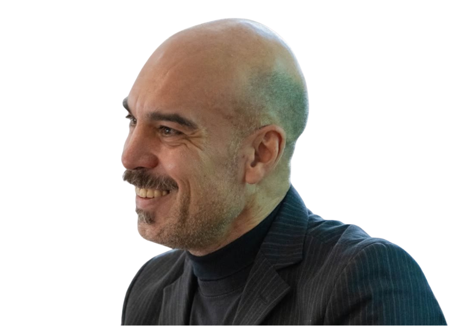

## Thanks to the Multiverse Gurus

**Paolo Girardi**

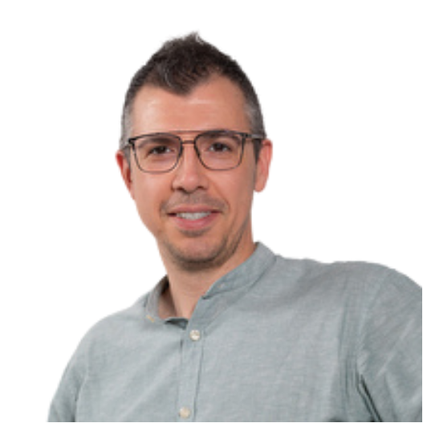

**Giulia Calignano**

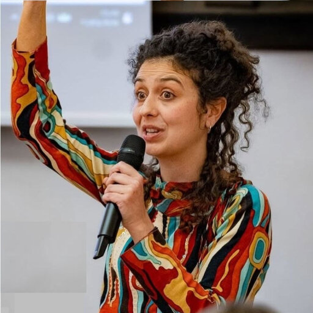

**Anna Vesely**

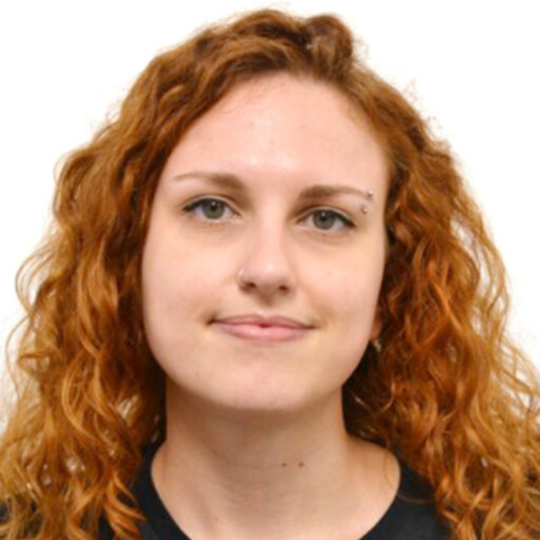

**Massimiliano Pastore**

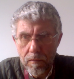

## Thanks to

**Psicostat**

[figure not shown]

**[Data, slides and code](https://drive.google.com/drive/folders/1lUneX7pbrZQnksynDQsFgY7I6TdX8Vmh?usp=sharing)**

[figure not shown]

manentematteo.github.io/resources

**For info**: *matteo.manente.3@phd.unipd.it*

# EXTRA

## Multiverse Meta-Analysis Takeaways

- **Be thoughtful**

  → Include only equally defensible choices (Del Giudice & Gangestad, 2021)
- **Be parsimonious**

  → Include only well-justified models for statistical power
- **Be exhaustive**

  → Account for all relevant variables to avoid inflated false positive rates

# Multiverse Meta-Analysis How?

## Step 1. Creating the Multiverse

| **Scenarios** | **Model** | **Therapy** | **Format** | **Bias** | **Diagnosis** |
| --- | --- | --- | --- | --- | --- |
| $m_1$ | EE | CBT | Individual | High | Clinical |
| $m_2$ | RE | Non-CBT | Group | Low | Cut-off |
| … | … | … | … | … | … |
| $m_{1920}$ | RE | All | All | All | All |

- Compute Meta-Analysis for each scenario ($m_i$)
- Include Meta-Analyses with at least 10 studies ($k \geq 10$)

## Step 2. Score calculation

- Compute score $z_k$ for every study *k* in each scenario $m_i$

$$z_k = \frac{y_k}{v_k + \tau_0^2}$$

$y_k$ = effect size estimate from study *k*

$v_k$ = variance of study *k*

$\tau_0^2$ = between-study variance **under the null** ($H_0$)

## Step 3. Score Matrix

- Store the scores $z_k$ in a matrix [*k x m*]

  → Rows = primary studies scores ($z_k$)

  → Columns = scenarios/meta-analyses ($m_i$)

|  | $m_1$ | $m_2$ | $m_i$ | $m_{1144}$ |
| --- | --- | --- | --- | --- |
| $k_1$ | 0.34 | 0.28 | … | 0.00 |
| $k_2$ | - 0.25 | 0.00 | … | -0.25 |
| … | … | … | … | … |
| $k_{124}$ | 0.00 | 0.52 | … | 0.48 |

*Null values (= 0.00) indicate study* $k_i$ was not included in meta-analysis $m_i$

## Step 4. Permutation-based Inference

- **Sign-flipping score test** (see Girardi et al., 2024)
  1. Randomly multiply each row $k_i$ by +1 or -1 (*sign-flipping*)  
     $\rightarrow$ equivalent to **re-sampling under the null hypothesis**
  2. Compute the **test statistic** (sum of scores) for each permuted scenario $m_i$
  3. Repeat *B* times $\rightarrow$ **null distribution** of each scenario $m_i$
  4. **Compare** observed scores *vs* permuted null distribution  
     $\rightarrow$ raw & **adjusted p-values** (*maxT*)

## Bonferroni Correction

- Easy fix for keeping the false positives rate $< 5\%$

$$\alpha_{adj} = \frac{\alpha_{standard}}{\text{number of tries (k)}}$$

- **Example**: if we do ten different tests on different data

$$\alpha_{adj} = \frac{0.05}{10} = 0.005$$

Now we are safe from false positives

…**but it’s incredibly hard to find true effects!**

## The Multiverse Reality

- Bonferroni assumes tests are **independent** (like coin tosses)
- But Multiverse specifications are **highly correlated**:  
  $\rightarrow$ *similar tests on the same data*
- Bonferroni ignores the correlations  
  $\rightarrow$ **Massive Power Loss** (High Type II Error)
- **maxT adjustment:**  
  1. empirically models the correlation structure via permutations  
  2. corrects for multiplicity without killing statistical power